# 🍷 Wine Quality Prediction Project

#### Using Machine Learning Techniques

## Import Libraries

In this step, we import required Python libraries for data analysis, visualization, and machine learning.

- pandas → data handling
- numpy → numerical operations
- matplotlib & seaborn → visualization

```python
import pandas as pd
import numpy as np
import matplotlib.pyplot as plt
import seaborn as sns
```

## Load Dataset

Here, we load red wine and white wine datasets using pandas. The separator used in dataset is ';' so we specify sep=';'.

```python
red = pd.read_csv("winequality-red.csv", sep=";")
white = pd.read_csv("winequality-white.csv", sep=";")
```

## View Data

We display first 5 rows of the dataset to understand the structure and features.

```python
print("Red Wine Data:")
print(red.head())

print("\nWhite Wine Data:")
print(white.head())
```

```
Red Wine Data:
   fixed acidity  volatile acidity  citric acid  residual sugar  chlorides  \
0            7.4              0.70         0.00             1.9      0.076
1            7.8              0.88         0.00             2.6      0.098
2            7.8              0.76         0.04             2.3      0.092
3           11.2              0.28         0.56             1.9      0.075
4            7.4              0.70         0.00             1.9      0.076

   free sulfur dioxide  total sulfur dioxide  density    pH  sulphates  \
0                 11.0                  34.0   0.9978  3.51       0.56
1                 25.0                  67.0   0.9968  3.20       0.68
2                 15.0                  54.0   0.9970  3.26       0.65
3                 17.0                  60.0   0.9980  3.16       0.58
4                 11.0                  34.0   0.9978  3.51       0.56

   alcohol  quality
0      9.4        5
1      9.8        5
2      9.8        5
3      9.8        6
4      9.4        5

White Wine Data:
   fixed acidity  volatile acidity  citric acid  residual sugar  chlorides  \
0            7.0              0.27         0.36            20.7      0.045
1            6.3              0.30         0.34             1.6      0.049
2            8.1              0.28         0.40             6.9      0.050
3            7.2              0.23         0.32             8.5      0.058
4            7.2              0.23         0.32             8.5      0.058

   free sulfur dioxide  total sulfur dioxide  density    pH  sulphates  \
0                 45.0                 170.0   1.0010  3.00       0.45
1                 14.0                 132.0   0.9940  3.30       0.49
2                 30.0                  97.0   0.9951  3.26       0.44
3                 47.0                 186.0   0.9956  3.19       0.40
4                 47.0                 186.0   0.9956  3.19       0.40

   alcohol  quality
0      8.8        6
1      9.5        6
2     10.1        6
3      9.9        6
4      9.9        6
```

## Dataset Information

We check dataset information such as:

- Column names
- Data types
- Missing values

```python
print(red.info())
print(white.info())
```

```
<class 'pandas.core.frame.DataFrame'>
RangeIndex: 1599 entries, 0 to 1598
Data columns (total 12 columns):
 #   Column                Non-Null Count  Dtype
---  ------                --------------  -----
 0   fixed acidity         1599 non-null   float64
 1   volatile acidity      1599 non-null   float64
 2   citric acid           1599 non-null   float64
 3   residual sugar        1599 non-null   float64
 4   chlorides             1599 non-null   float64
 5   free sulfur dioxide   1599 non-null   float64
 6   total sulfur dioxide  1599 non-null   float64
 7   density               1599 non-null   float64
 8   pH                    1599 non-null   float64
 9   sulphates             1599 non-null   float64
 10  alcohol               1599 non-null   float64
 11  quality               1599 non-null   int64
dtypes: float64(11), int64(1)
memory usage: 150.0 KB
None
<class 'pandas.core.frame.DataFrame'>
RangeIndex: 4898 entries, 0 to 4897
Data columns (total 12 columns):
 #   Column                Non-Null Count  Dtype
---  ------                --------------  -----
 0   fixed acidity         4898 non-null   float64
 1   volatile acidity      4898 non-null   float64
 2   citric acid           4898 non-null   float64
 3   residual sugar        4898 non-null   float64
 4   chlorides             4898 non-null   float64
 5   free sulfur dioxide   4898 non-null   float64
 6   total sulfur dioxide  4898 non-null   float64
 7   density               4898 non-null   float64
 8   pH                    4898 non-null   float64
 9   sulphates             4898 non-null   float64
 10  alcohol               4898 non-null   float64
 11  quality               4898 non-null   int64
dtypes: float64(11), int64(1)
memory usage: 459.3 KB
None
```

## Data Visualization

We visualize the distribution of wine quality using count plots. This helps us understand how many samples belong to each quality category.

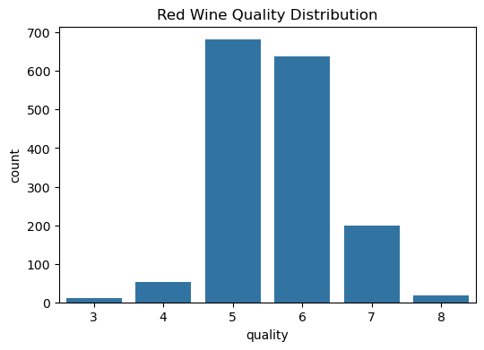

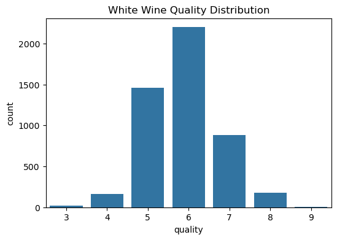

```python
plt.figure(figsize=(6,4))
sns.countplot(x='quality', data=red)
plt.title("Red Wine Quality Distribution")
plt.show()

plt.figure(figsize=(6,4))
sns.countplot(x='quality', data=white)
plt.title("White Wine Quality Distribution")
plt.show()
```

## Correlation Heatmap

Heatmap shows the relationship between different features. Higher values indicate strong correlation.

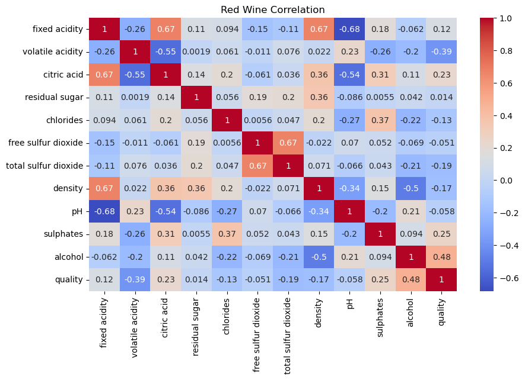

```python
plt.figure(figsize=(10,6))
sns.heatmap(red.corr(), annot=True, cmap="coolwarm")
plt.title("Red Wine Correlation")
plt.show()
```

## Data Preparation

We separate features (X) and target variable (y). Target variable is 'quality'.

```python
X_red = red.drop("quality", axis=1)
y_red = red["quality"]

X_white = white.drop("quality", axis=1)
y_white = white["quality"]
```

## Train-Test Split

We split the dataset into training and testing data. 80% data is used for training and 20% for testing.

```python
from sklearn.model_selection import train_test_split

Xr_train, Xr_test, yr_train, yr_test = train_test_split(X_red, y_red, test_size=0.2, random_state=42)

Xw_train, Xw_test, yw_train, yw_test = train_test_split(X_white, y_white, test_size=0.2, random_state=42)
```

## Model Training

We use Random Forest Classifier to train the model. It is an ensemble learning method that gives good accuracy.

```python
from sklearn.ensemble import RandomForestClassifier

model_red = RandomForestClassifier()
model_red.fit(Xr_train, yr_train)

model_white = RandomForestClassifier()
model_white.fit(Xw_train, yw_train)
```

```
RandomForestClassifier()
```

## Predictions

We use trained model to predict wine quality on test data.

```python
yr_pred = model_red.predict(Xr_test)
yw_pred = model_white.predict(Xw_test)
```

## Accuracy Score

Accuracy shows how many predictions are correct out of total predictions.

```python
from sklearn.metrics import accuracy_score

print("Red Wine Accuracy:", accuracy_score(yr_test, yr_pred))
print("White Wine Accuracy:", accuracy_score(yw_test, yw_pred))
```

```
Red Wine Accuracy: 0.65
White Wine Accuracy: 0.6938775510204082
```

## Confusion Matrix

Confusion Matrix shows the performance of classification model. It compares actual values with predicted values.

```python
from sklearn.metrics import confusion_matrix

print("Red Wine Confusion Matrix:")
print(confusion_matrix(yr_test, yr_pred))

print("\nWhite Wine Confusion Matrix:")
print(confusion_matrix(yw_test, yw_pred))
```

```
Red Wine Confusion Matrix:
[[ 0  0  1  0  0  0]
 [ 0  0  6  4  0  0]
 [ 0  0 96 34  0  0]
 [ 0  1 30 94  7  0]
 [ 0  0  0 23 18  1]
 [ 0  0  0  1  4  0]]

White Wine Confusion Matrix:
[[  0   0   1   4   0   0]
 [  0   5  11   9   0   0]
 [  0   3 204  81   3   0]
 [  0   0  69 340  23   0]
 [  0   0   3  70 116   3]
 [  0   0   1   9  10  15]]
```

Confusion Matrix helps in understanding which classes are predicted correctly and where the model makes mistakes.

- Model struggles between quality 5 and 6
- White wine model performs slightly better

Final Conclusion

- White dataset gives better accuracy due to larger data size
- Random Forest model performs well
- Some overlapping classes reduce prediction accuracy

## 🏁 Final Conclusion

This project focused on predicting wine quality using machine learning techniques on both red and white wine datasets.

**🔍 Key Findings:**

- The **Random Forest model** performed well in predicting wine quality.
- The **White wine dataset** showed slightly better accuracy compared to red wine due to larger data size.
- Some quality classes (especially **5 and 6**) were harder to distinguish, leading to minor prediction errors.

**📊 Overall Insight:**  
The model successfully captured important patterns in the dataset and provided reliable predictions, although overlapping classes slightly affected accuracy.

**🚀 Conclusion:**  
Machine learning models like Random Forest can effectively predict wine quality and can be further improved with advanced techniques and feature engineering.